# The relationship between GDP per Capita and Number of working hours per week.

Siddhant Rao

2023-11-08

```r
knitr::opts_chunk$set(echo = TRUE)
```

```r
library("gapminder")
library("dplyr")
```

```r
library("ggplot2")
library("tidyr")
library("ggpubr")
library("cluster")
```

**INTRODUCTION**

We are trying to understand the relationship between GDP per capita and the number of working hours worked per week.

The motivation for us to choose this topic was because it is the general idea that if people work longer, they are obligated to earn more. There is a common cultural sentiment to work longer to expect more monetary rewards. Logically and morally it does seem appropriate that the more the effort put in by an individual, the more they would be compensated.

This idea has always appeased Hardworking individuals however we want to understand if there is substantial evidence backing this idea or is this a thought of the past which may not bear much fruits in today’s day and age.

To keep things uniform, all comparisons done are over multiple countries across the world, this helps eliminate bias against any single country. This does not consider ethnicity or other parameters which may introduce biases, it simply looks at Income as GDP per capital and the actual number of hours worked per week.

To achieve this, we have undertaken the following tasks :

- Data Import and loading from Downloaded files.
- Data Transformation and cleaning
- Data Visualization, Regression and Correlation
- Cluster Analysis
- Results and Observations

This topic is novel to us because it goes beyond the rationale thought process to work harder to maximize wealth, if proved true, the evidence provided must support this view from the data provided.

**1. DATA IMPORTING AND LOADING**

We read in our CSV Data. The data files used are from the gapminder website which are readily available for download.

```r
workingHoursData = read.csv("working_hours_per_week.csv");
gdpData = read.csv("gdp_pcap.csv")
countries_by_income = read.csv("country_income.csv")
```

The original dataset of Working_hours_per_week and gdp_pcap does not have region wise segregation and income wise segregation information. In order to get this information, We append the data columns with `countries_by_income` created using data from gapminder against the GDP per capita and working hours per week. This provides additional categories of Region and IncomeGroup to our data which helps us summarize and analyze our data effectively.

```r
gdpData <- countries_by_income %>% left_join(gdpData, by = c("Name" = "country"))
workingHoursData <- countries_by_income %>% left_join(workingHoursData, by = c("Name" = "country"))
head(gdpData, 10)
```

```
##                   Name                     Region         IncomeGroup X1987
## 1          Afghanistan                 South Asia          Low income  1850
## 2              Albania      Europe & Central Asia Upper middle income  5320
## 3              Algeria Middle East & North Africa Upper middle income  8380
## 4       American Samoa        East Asia & Pacific Upper middle income  <NA>
## 5              Andorra      Europe & Central Asia         High income 41.8k
## 6               Angola         Sub-Saharan Africa Upper middle income  3990
## 7  Antigua and Barbuda  Latin America & Caribbean         High income 15.1k
## 8            Argentina  Latin America & Caribbean         High income 16.3k
## 9              Armenia      Europe & Central Asia Lower middle income  7140
## 10               Aruba  Latin America & Caribbean         High income  <NA>
##    X1988 X1989 X1990 X1991 X1992 X1993 X1994 X1995 X1996 X1997 X1998 X1999
## 1   1690  1540  1480  1360  1310   897   666   986   937   892   854   815
## 2   5210  5470  5020  3650  3430  3770  4090  4600  5020  4490  4910  5580
## 3   8010  8190  8100  7930  7990  7740  7600  7820  8070  8090  8430  8630
```

[output cut: 29 more lines]

**2. DATA CLEANING AND TRANSFORMATION**

In the GDP Data Frame, we can see that some column fields have a numeric description such as 5320 etc, but some has a character description such as 31.4k or 32.1k. Therefore we will first need to clean our data, handle NA values, convert the character into numeric format and represent the number in decimal format, for example, we need to represent 31.4k as 31400

We also have another issue that the years is not represented as a column, rather a row. We will not be able to combine data if the year is depicted as rows and hence we will have to use `pivot_longer` to transform the years as rows into columns.

We can first write a function to perform the above, to check the character in each cell and convert them into numeric field. We can then apply the function on each column to transform the data.

```r
convert_values <- function(x) {
  if(is.na(x) || x == "") {
    return(NA)
  } else if(grepl("^[0-9.]+k$", x)) {
    return(as.numeric(substr(x, 1, nchar(x) - 1)) * 1000)
  } else if(grepl("^[0-9.]+$", x)) {
    return(as.numeric(x))
  } else {
    return(x)
  }
}

gdpData <- as.data.frame(lapply(gdpData, function(col) {
  if (is.character(col)) {
    return(sapply(col, convert_values))
  } else {
    return(col)
  }
}))

workingHoursData <- as.data.frame(lapply(workingHoursData, function(col) {
  if (is.character(col) || is.double(col)) {
    return(sapply(col, convert_values))
  } else {
    return(col)
  }
}))

working_hours_week_long <- workingHoursData %>%
  pivot_longer(cols = starts_with("X"),
               names_to = "year",
               values_to = "working_hours")

gdp_data_long <- gdpData %>%
  pivot_longer(cols = starts_with("X"),
               names_to = "year",
               values_to = "gdp")

working_hours_week_long
```

```
## # A tibble: 7,276 × 5
##    Name        Region     IncomeGroup year  working_hours
##    <chr>       <chr>      <chr>       <chr>         <dbl>
##  1 Afghanistan South Asia Low income  X1987            NA
##  2 Afghanistan South Asia Low income  X1988            NA
##  3 Afghanistan South Asia Low income  X1989            NA
##  4 Afghanistan South Asia Low income  X1990            NA
##  5 Afghanistan South Asia Low income  X1991            NA
##  6 Afghanistan South Asia Low income  X1992            NA
##  7 Afghanistan South Asia Low income  X1993            NA
##  8 Afghanistan South Asia Low income  X1994            NA
##  9 Afghanistan South Asia Low income  X1995            NA
## 10 Afghanistan South Asia Low income  X1996            NA
## # ℹ 7,266 more rows
```

```r
gdp_data_long
```

```
## # A tibble: 7,276 × 5
##    Name        Region     IncomeGroup year    gdp
##    <chr>       <chr>      <chr>       <chr> <dbl>
##  1 Afghanistan South Asia Low income  X1987  1850
##  2 Afghanistan South Asia Low income  X1988  1690
##  3 Afghanistan South Asia Low income  X1989  1540
##  4 Afghanistan South Asia Low income  X1990  1480
##  5 Afghanistan South Asia Low income  X1991  1360
##  6 Afghanistan South Asia Low income  X1992  1310
##  7 Afghanistan South Asia Low income  X1993   897
##  8 Afghanistan South Asia Low income  X1994   666
##  9 Afghanistan South Asia Low income  X1995   986
## 10 Afghanistan South Asia Low income  X1996   937
## # ℹ 7,266 more rows
```

**3. DATA VISUALIZATION, REGRESSION AND CORRELATION**

In order to understand the relationship between the working hours per week and gdp per data, we can use scatter plots to understand relations between them. Since we have many countries and we want to find a relation between GDP and working hours per week, it would be better to start by grouping countries based on Income levels to check for any patterns or relations compared to Region which may not give the best indications when we are looking for trends in Income/GDP.

```r
precheck_df_workWeek <- working_hours_week_long %>%
  group_by(year, IncomeGroup) %>%
  summarize(WorkWeek_mean = mean(working_hours, na.rm = TRUE))
precheck_df_gdp <- gdp_data_long %>%
  group_by(year, IncomeGroup) %>%
  summarize(gdp_mean = mean(gdp, na.rm = TRUE))
precheck_df_gdp
```

```
## # A tibble: 136 × 3
## # Groups:   year [34]
##    year  IncomeGroup         gdp_mean
##    <chr> <chr>                  <dbl>
##  1 X1987 High income           28278.
##  2 X1987 Low income             1633.
##  3 X1987 Lower middle income    4319.
##  4 X1987 Upper middle income    8855.
##  5 X1988 High income           29011.
##  6 X1988 Low income             1647.
##  7 X1988 Lower middle income    4364.
##  8 X1988 Upper middle income    8944.
##  9 X1989 High income           29700.
## 10 X1989 Low income             1635.
## # ℹ 126 more rows
```

```r
# Handling cases for NaN
precheck_df_workWeek <- precheck_df_workWeek[!is.nan(precheck_df_workWeek$WorkWeek_mean), ]
```

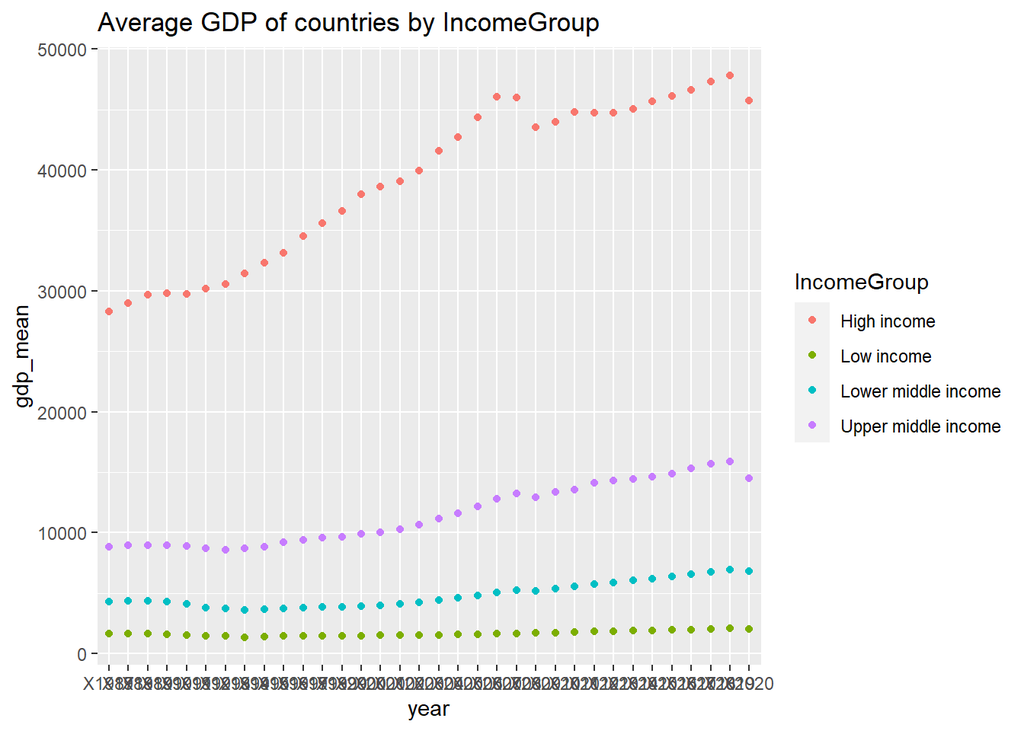

```r
ggplot(data = precheck_df_gdp, aes(x = year, y = gdp_mean, color = IncomeGroup)) +
    geom_point() +
 labs(title = "Average GDP of countries by IncomeGroup")
```

On Looking at the above Scatter Plot of `Average GDP of countries by IncomeGroup` we can see a clear trend on High income countries of growing GDP over the number of years. It is intriguing however to see a very moderate rise in GDP in Upper middle income countries and Lower middle income countries.

Moving to Working Hours per week, the below code will generate a scatter plot to examine relations in working hours per week between countries based on Incomegroup.

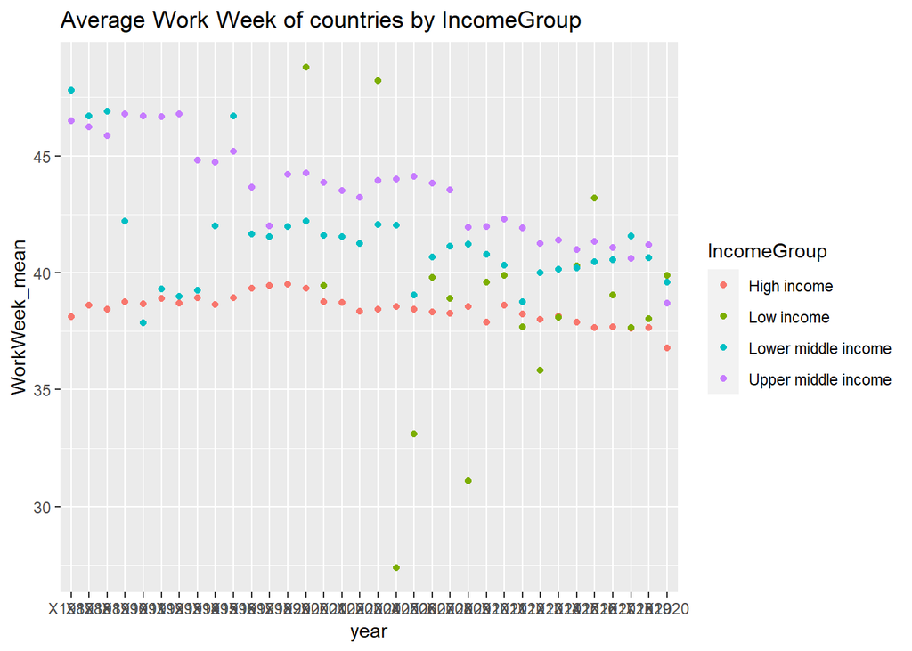

```r
ggplot(data = precheck_df_workWeek, aes(x = year, y = WorkWeek_mean, color = IncomeGroup)) +
    geom_point() +
 labs(title = "Average Work Week of countries by IncomeGroup")
```

Here we see that the upper middle income group has a decreasing number of working hours per week, although there are some missing points at certain intervals and is generally decreasing, it is not decreasing at a rapid rate, we see a similar situation with the Lower middle income class group, in this case, the decrease of working hours per week is minimal. However in case of the High income groups, the drop is the least compared to all others, it tends to stay constant in a small interval. The discrepency of decrease of number of working hours per week between different groups pushes us to investigate further.

Since we are finding relationships between GDP and number of working hours per week for a set of countries based on income as a whole, and not solely each individual country, it wouldn’t be meaningful to consider working hours and GDP for individual countries, rather we would need to consider group of countries and hence we will have to use average GDP and average working hours per week of the constituent countries associated with an Income Group.

**3.1 CORRELATION OF GDP AND NUMBER OF WORKING HOURS IN UPPER MIDDLE INCOME COUNTRIES**

```r
upperMiddleIncomeCountry_gdp_data <- gdp_data_long %>% filter(IncomeGroup == "Upper middle income")
upperMiddleIncomeCountry_work_week_data <- working_hours_week_long %>% filter(IncomeGroup == "Upper middle income")

upperMiddleIncomeCountry_gdp_data_mean <- upperMiddleIncomeCountry_gdp_data %>%
  group_by(year, IncomeGroup) %>%
  summarize(avg_gdp = mean(gdp, na.rm = TRUE))
upperMiddleIncomeCountry_work_week_data_mean <- upperMiddleIncomeCountry_work_week_data %>%
  group_by(year, IncomeGroup) %>%
  summarize(avg_working_hours = mean(working_hours, na.rm = TRUE))
# Since we want to compare gdp data with working hours per week, they both are on different timeframes, we will use the log function to scale them both to the same measurement.
#NOTE: This is not a true value of gdp or working hours per week but rather a scaled representation.
# We divide by 52 because our gdp per capita data is based on yearly data while we are comparing it to number of hours worked per week and hence we are converting both into a weekly timeframe.

upperMiddleIncomeCountry_gdp_data_mean$avg_gdp <- log((upperMiddleIncomeCountry_gdp_data_mean$avg_gdp)/52)
upperMiddleIncomeCountry_work_week_data_mean$avg_working_hours <- log(upperMiddleIncomeCountry_work_week_data_mean$avg_working_hours)
upperMiddleIncomeCountry_work_week_data_mean
```

```
## # A tibble: 34 × 3
## # Groups:   year [34]
##    year  IncomeGroup         avg_working_hours
##    <chr> <chr>                           <dbl>
##  1 X1987 Upper middle income              3.84
##  2 X1988 Upper middle income              3.83
##  3 X1989 Upper middle income              3.83
##  4 X1990 Upper middle income              3.85
##  5 X1991 Upper middle income              3.84
##  6 X1992 Upper middle income              3.84
##  7 X1993 Upper middle income              3.85
##  8 X1994 Upper middle income              3.80
##  9 X1995 Upper middle income              3.80
## 10 X1996 Upper middle income              3.81
## # ℹ 24 more rows
```

```r
combined_data_upperMiddleIncomeCountry <- inner_join(upperMiddleIncomeCountry_work_week_data_mean, upperMiddleIncomeCountry_gdp_data_mean, by = c("IncomeGroup", "year"))
combined_data_upperMiddleIncomeCountry
```

```
## # A tibble: 34 × 4
## # Groups:   year [34]
##    year  IncomeGroup         avg_working_hours avg_gdp
##    <chr> <chr>                           <dbl>   <dbl>
##  1 X1987 Upper middle income              3.84    5.14
##  2 X1988 Upper middle income              3.83    5.15
##  3 X1989 Upper middle income              3.83    5.15
##  4 X1990 Upper middle income              3.85    5.15
##  5 X1991 Upper middle income              3.84    5.14
##  6 X1992 Upper middle income              3.84    5.12
##  7 X1993 Upper middle income              3.85    5.10
##  8 X1994 Upper middle income              3.80    5.12
##  9 X1995 Upper middle income              3.80    5.14
## 10 X1996 Upper middle income              3.81    5.17
## # ℹ 24 more rows
```

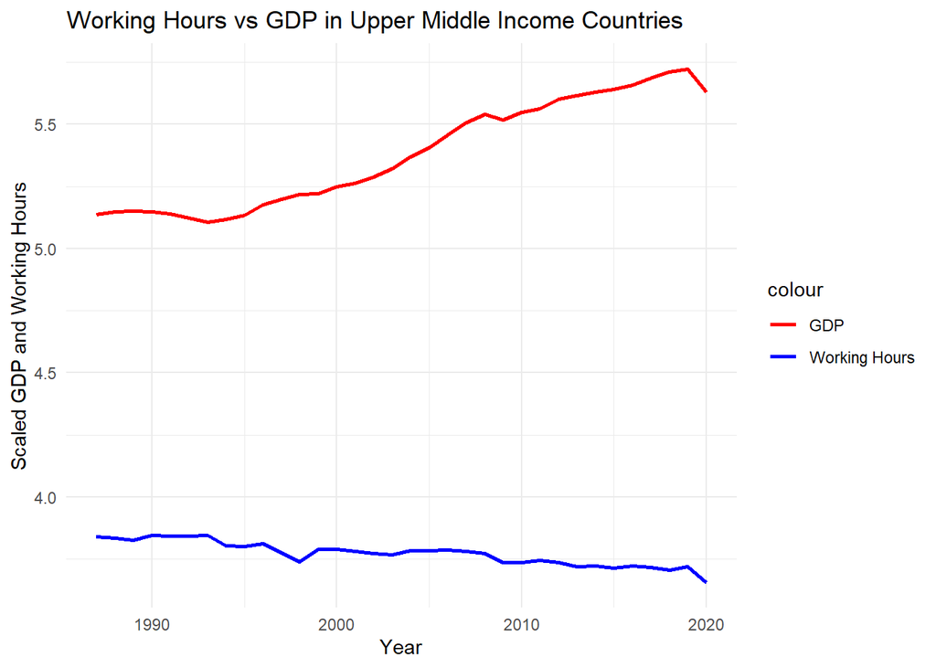

```r
ggplot(data = combined_data_upperMiddleIncomeCountry) +
  geom_line(aes(x = as.numeric(sub("X", "", year)), y = avg_working_hours, color = "Working Hours"), size = 1) +
  geom_line(aes(x = as.numeric(sub("X", "", year)), y = avg_gdp, color = "GDP"), size = 1) +
  labs(title = "Working Hours vs GDP in Upper Middle Income Countries",
       x = "Year",
       y = "Scaled GDP and Working Hours") +
  theme_minimal() +
  scale_color_manual(values = c("Working Hours" = "blue", "GDP" = "red"))
```

We can see an increase in GDP per capita of these groups of countries, it corresponds to a shift in number of working hours. On careful inspection of the graph, we can see that number of working hours decreases over time, as GDP per capita increases.

Now that we have a basic understanding of this relationship, we can form a regression to understand the relationship between these values.

```r
model_upperMiddle_income <- lm(avg_working_hours ~ avg_gdp, data = combined_data_upperMiddleIncomeCountry)
summary(model_upperMiddle_income)
```

```
##
## Call:
## lm(formula = avg_working_hours ~ avg_gdp, data = combined_data_upperMiddleIncomeCountry)
##
## Residuals:
##       Min        1Q    Median        3Q       Max
## -0.066724 -0.012458  0.001702  0.017468  0.033228
##
## Coefficients:
##             Estimate Std. Error t value Pr(>|t|)
## (Intercept)  4.82821    0.10455   46.18  < 2e-16 ***
## avg_gdp     -0.19635    0.01942  -10.11 1.72e-11 ***
## ---
## Signif. codes:  0 '***' 0.001 '**' 0.01 '*' 0.05 '.' 0.1 ' ' 1
##
## Residual standard error: 0.02411 on 32 degrees of freedom
## Multiple R-squared:  0.7617, Adjusted R-squared:  0.7542
## F-statistic: 102.3 on 1 and 32 DF,  p-value: 1.723e-11
```

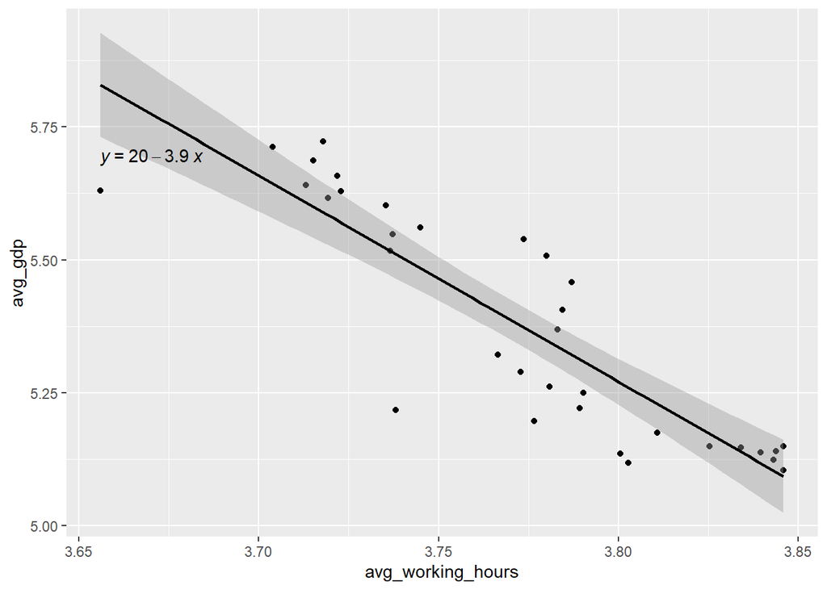

```r
combine_graph_uppermiddle <- ggplot(combined_data_upperMiddleIncomeCountry, aes(x=avg_working_hours, y=avg_gdp)) + geom_point() + geom_smooth(method="lm", col="black") + stat_regline_equation()
combine_graph_uppermiddle
```

We can perform a similar analysis for High Income countries and Low Income countries as well.

**3.2 CORRELATION OF GDP AND NUMBER OF WORKING HOURS IN HIGH INCOME COUNTRIES**

```r
HighIncomeCountry_gdp_data <- gdp_data_long %>% filter(IncomeGroup == "High income")
HighIncomeCountry_work_week_data <- working_hours_week_long %>% filter(IncomeGroup == "High income")

HighIncomeCountry_gdp_data_mean <- HighIncomeCountry_gdp_data %>%
  group_by(year, IncomeGroup) %>%
  summarize(avg_gdp = mean(gdp, na.rm = TRUE))
HighIncomeCountry_work_week_data_mean <- HighIncomeCountry_work_week_data %>%
  group_by(year, IncomeGroup) %>%
  summarize(avg_working_hours = mean(working_hours, na.rm = TRUE))
# Since we want to compare gdp data with working hours per week, since they both are on different timeframes, we will use the scale function to scale them both to the same measurement.
#NOTE: This is not a true value of gdp or working hours per week but rather a scaled representation.
# We divide by 52 because our gdp per capita data is based on yearly data while we are comparing it to number of hours worked per week and hence we are converting both into a weekly timeframe.

HighIncomeCountry_gdp_data_mean$avg_gdp <- log((HighIncomeCountry_gdp_data_mean$avg_gdp)/52)
HighIncomeCountry_work_week_data_mean$avg_working_hours <- log(HighIncomeCountry_work_week_data_mean$avg_working_hours)


combined_data_HighIncomeCountry <- inner_join(HighIncomeCountry_work_week_data_mean, HighIncomeCountry_gdp_data_mean, by = c("IncomeGroup", "year"))
combined_data_HighIncomeCountry
```

```
## # A tibble: 34 × 4
## # Groups:   year [34]
##    year  IncomeGroup avg_working_hours avg_gdp
##    <chr> <chr>                   <dbl>   <dbl>
##  1 X1987 High income              3.64    6.30
##  2 X1988 High income              3.65    6.32
##  3 X1989 High income              3.65    6.35
##  4 X1990 High income              3.66    6.35
##  5 X1991 High income              3.65    6.35
##  6 X1992 High income              3.66    6.36
##  7 X1993 High income              3.66    6.38
##  8 X1994 High income              3.66    6.40
##  9 X1995 High income              3.65    6.43
## 10 X1996 High income              3.66    6.46
## # ℹ 24 more rows
```

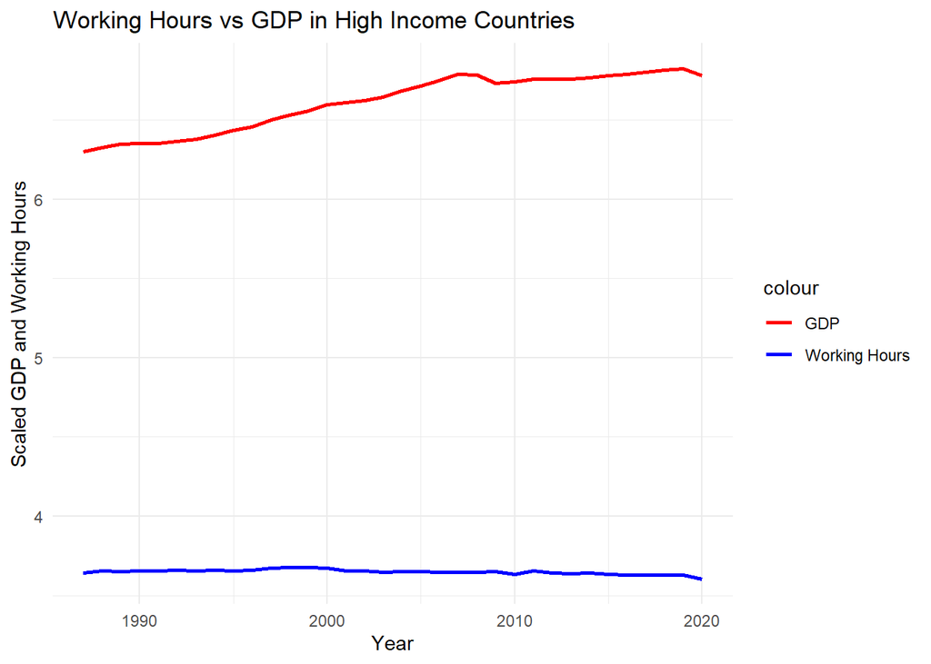

```r
ggplot(data = combined_data_HighIncomeCountry) +
  geom_line(aes(x = as.numeric(sub("X", "", year)), y = avg_working_hours, color = "Working Hours"), size = 1) +
  geom_line(aes(x = as.numeric(sub("X", "", year)), y = avg_gdp, color = "GDP"), size = 1) +
  labs(title = "Working Hours vs GDP in High Income Countries",
       x = "Year",
       y = "Scaled GDP and Working Hours") +
  theme_minimal() +
  scale_color_manual(values = c("Working Hours" = "blue", "GDP" = "red"))
```

It is seen that an increase in GDP per capita of High income group of countries is inversely proportional to number of working hours per week. On careful inspection of the graph, we can see that number of working hours decreases over time as GDP per capita increases but by a smaller margin compared to previous working hours trendline.

Just like before, we can form a regression to understand the relationship between these values.

```r
model_High_income <- lm(avg_working_hours ~ avg_gdp + 0, data = combined_data_HighIncomeCountry)
summary(model_High_income)
```

```
##
## Call:
## lm(formula = avg_working_hours ~ avg_gdp + 0, data = combined_data_HighIncomeCountry)
##
## Residuals:
##      Min       1Q   Median       3Q      Max
## -0.13580 -0.08952 -0.02710  0.10471  0.16692
##
## Coefficients:
##         Estimate Std. Error t value Pr(>|t|)
## avg_gdp 0.551559   0.002791   197.6   <2e-16 ***
## ---
## Signif. codes:  0 '***' 0.001 '**' 0.01 '*' 0.05 '.' 0.1 ' ' 1
##
## Residual standard error: 0.1076 on 33 degrees of freedom
## Multiple R-squared:  0.9992, Adjusted R-squared:  0.9991
## F-statistic: 3.905e+04 on 1 and 33 DF,  p-value: < 2.2e-16
```

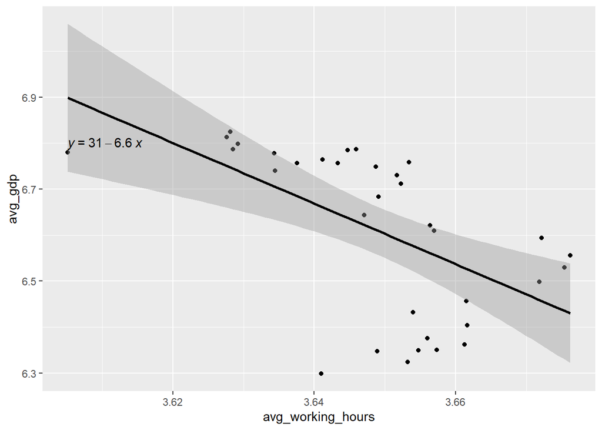

```r
combine_graph_High <- ggplot(combined_data_HighIncomeCountry, aes(x=avg_working_hours, y=avg_gdp)) + geom_point() + geom_smooth(method="lm", col="black") + stat_regline_equation()
combine_graph_High
```

Finally looking at Low income countries:

**3.3 CORRELATION OF GDP AND NUMBER OF WORKING HOURS IN LOW INCOME COUNTRIES**

```r
LowIncomeCountry_gdp_data <- gdp_data_long %>% filter(IncomeGroup == "Low income")
LowIncomeCountry_work_week_data <- working_hours_week_long %>% filter(IncomeGroup == "Low income")

LowIncomeCountry_gdp_data_mean <- LowIncomeCountry_gdp_data %>%
  group_by(year, IncomeGroup) %>%
  summarize(avg_gdp = mean(gdp, na.rm = TRUE))
LowIncomeCountry_work_week_data_mean <- LowIncomeCountry_work_week_data %>%
  group_by(year, IncomeGroup) %>%
  summarize(avg_working_hours = mean(working_hours, na.rm = TRUE))
# Since we want to compare gdp data with working hours per week, since they both are on different timeframes, we will use the scale function to scale them both to the same measurement.
#NOTE: This is not a true value of gdp or working hours per week but rather a scaled representation.
# We divide by 52 because our gdp per capita data is based on yearly data while we are comparing it to number of hours worked per week and hence we are converting both into a weekly timeframe.

LowIncomeCountry_gdp_data_mean$avg_gdp <- log((LowIncomeCountry_gdp_data_mean$avg_gdp)/52)
LowIncomeCountry_gdp_data_mean
```

```
## # A tibble: 34 × 3
## # Groups:   year [34]
##    year  IncomeGroup avg_gdp
##    <chr> <chr>         <dbl>
##  1 X1987 Low income     3.45
##  2 X1988 Low income     3.46
##  3 X1989 Low income     3.45
##  4 X1990 Low income     3.41
##  5 X1991 Low income     3.40
##  6 X1992 Low income     3.35
##  7 X1993 Low income     3.32
##  8 X1994 Low income     3.27
##  9 X1995 Low income     3.30
## 10 X1996 Low income     3.32
## # ℹ 24 more rows
```

```r
LowIncomeCountry_work_week_data_mean <- LowIncomeCountry_work_week_data_mean[!apply(LowIncomeCountry_work_week_data_mean == 0, 1, any), ]
LowIncomeCountry_work_week_data_mean$avg_working_hours <- log(LowIncomeCountry_work_week_data_mean$avg_working_hours)
LowIncomeCountry_work_week_data_mean
```

```
## # A tibble: 34 × 3
## # Groups:   year [20]
##    year  IncomeGroup avg_working_hours
##    <chr> <chr>                   <dbl>
##  1 <NA>  <NA>                       NA
##  2 <NA>  <NA>                       NA
##  3 <NA>  <NA>                       NA
##  4 <NA>  <NA>                       NA
##  5 <NA>  <NA>                       NA
##  6 <NA>  <NA>                       NA
##  7 <NA>  <NA>                       NA
##  8 <NA>  <NA>                       NA
##  9 <NA>  <NA>                       NA
## 10 <NA>  <NA>                       NA
## # ℹ 24 more rows
```

```r
combined_data_LowIncomeCountry <- inner_join(LowIncomeCountry_work_week_data_mean, LowIncomeCountry_gdp_data_mean, by = c("IncomeGroup", "year"))
combined_data_LowIncomeCountry
```

```
## # A tibble: 19 × 4
## # Groups:   year [19]
##    year  IncomeGroup avg_working_hours avg_gdp
##    <chr> <chr>                   <dbl>   <dbl>
##  1 X2000 Low income               3.89    3.36
##  2 X2001 Low income               3.68    3.38
##  3 X2004 Low income               3.88    3.40
##  4 X2005 Low income               3.31    3.41
##  5 X2006 Low income               3.50    3.43
##  6 X2007 Low income               3.68    3.45
##  7 X2008 Low income               3.66    3.46
##  8 X2009 Low income               3.44    3.48
##  9 X2010 Low income               3.68    3.52
## 10 X2011 Low income               3.69    3.55
## 11 X2012 Low income               3.63    3.56
## 12 X2013 Low income               3.58    3.58
## 13 X2014 Low income               3.64    3.61
## 14 X2015 Low income               3.70    3.61
## 15 X2016 Low income               3.77    3.62
## 16 X2017 Low income               3.67    3.64
## 17 X2018 Low income               3.63    3.66
## 18 X2019 Low income               3.64    3.68
## 19 X2020 Low income               3.69    3.65
```

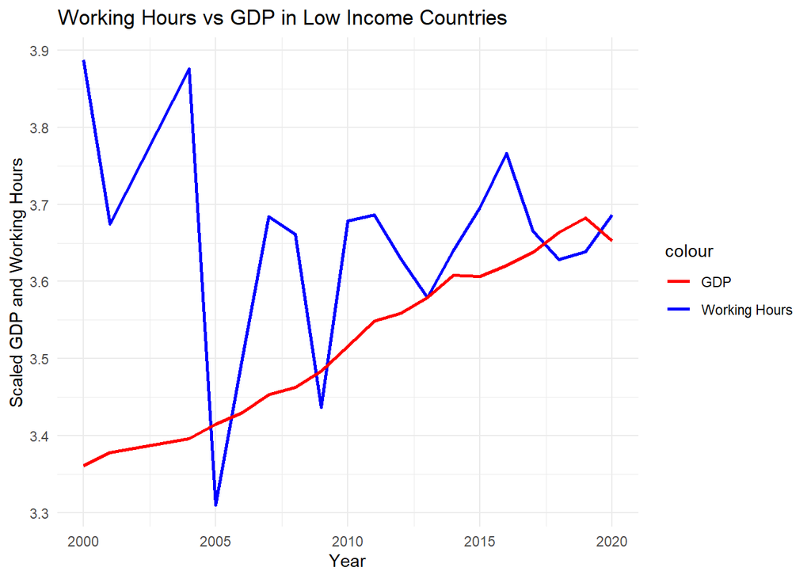

```r
ggplot(data = combined_data_LowIncomeCountry) +
  geom_line(aes(x = as.numeric(sub("X", "", year)), y = avg_working_hours, color = "Working Hours"), size = 1) +
  geom_line(aes(x = as.numeric(sub("X", "", year)), y = avg_gdp, color = "GDP"), size = 1) +
  labs(title = "Working Hours vs GDP in Low Income Countries",
       x = "Year",
       y = "Scaled GDP and Working Hours") +
  theme_minimal() +
  scale_color_manual(values = c("Working Hours" = "blue", "GDP" = "red"))
```

We do see a clear increase in the GDP per capita for low income countries, however, The working hour per week in low income countries is rather choppy and does not provide a clear guidance for a correlation.

Taking a look at the regression equation:

```r
model_Low_income <- lm(avg_working_hours ~ avg_gdp, data = combined_data_LowIncomeCountry)
summary(model_Low_income)
```

```
##
## Call:
## lm(formula = avg_working_hours ~ avg_gdp, data = combined_data_LowIncomeCountry)
##
## Residuals:
##      Min       1Q   Median       3Q      Max
## -0.33964 -0.01883  0.01790  0.03874  0.23681
##
## Coefficients:
##             Estimate Std. Error t value Pr(>|t|)
## (Intercept)  3.69689    1.08658   3.402  0.00339 **
## avg_gdp     -0.01368    0.30775  -0.044  0.96506
## ---
## Signif. codes:  0 '***' 0.001 '**' 0.01 '*' 0.05 '.' 0.1 ' ' 1
##
## Residual standard error: 0.1367 on 17 degrees of freedom
## Multiple R-squared:  0.0001162,  Adjusted R-squared:  -0.0587
## F-statistic: 0.001976 on 1 and 17 DF,  p-value: 0.9651
```

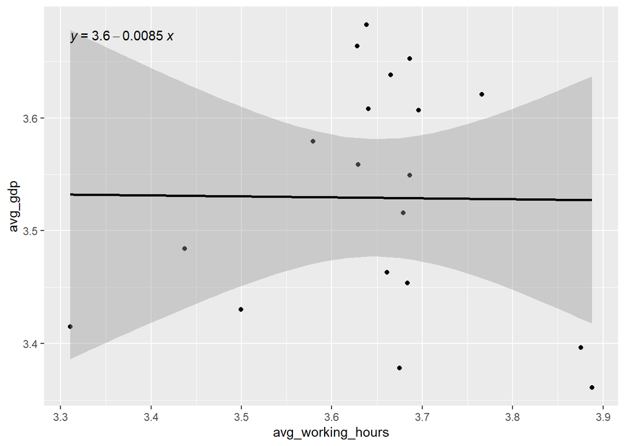

```r
combine_graph_Low <- ggplot(combined_data_LowIncomeCountry, aes(x=avg_working_hours, y=avg_gdp)) + geom_point() + geom_smooth(method="lm", col="black") + stat_regline_equation()
combine_graph_Low
```

This seems to be interesting, although the initial graph did not give a direction for the number of working hours per week, the regression equation indicates a very slight change with the dependent variable. a small factor of 0.0085, which means a unit change in the gdp per capita of an individual in a country from the low income group has seen a reduction in working hours over the year by a factor of 0.0085. This is not a large change compared to what is seen previously.

We come to an important finding while checking the three groups. The relation between the Average gdp per capita of an individual in each country compared to number of working hours per week is as follows:

```
    1. For High Income Countries              : y = 31 - 6.6x
    2. For Upper Middle Income Countries      : y = 20 - 3.9x
    3. For Low Income Countries               : y = 3.6 - 0.0085x
```

We can see that the magnitude of shift in working hours per week decreases as we move from Higher income countries to lower income countries. This can be shown in a cluster analysis as well.

**4. CLUSTER ANALYSIS**

**4.1 USING ELBOW METHOD TO FIND APPROPRIATE K-VALUES.**

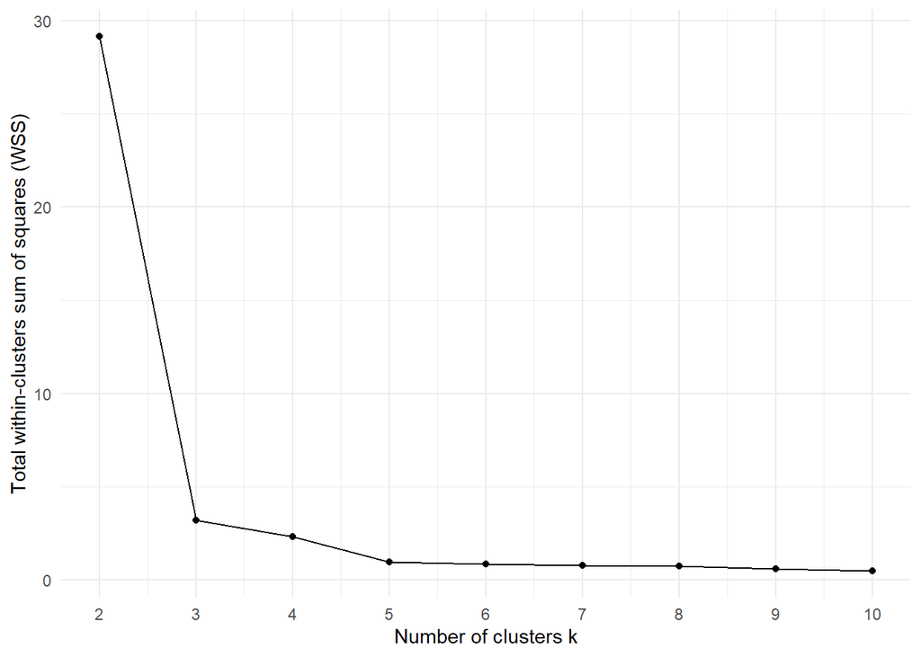

```r
kfind_df_cluster <- rbind(combined_data_HighIncomeCountry, combined_data_upperMiddleIncomeCountry, combined_data_LowIncomeCountry)
kfind_clustering_data <- kfind_df_cluster[, c("avg_working_hours", "avg_gdp")]

wss <- (nrow(kfind_clustering_data)-1)*sum(apply(kfind_clustering_data,2,var))
for (i in 2:10) {
  set.seed(123)
  wss[i] <- sum(kmeans(kfind_clustering_data, centers=i)$withinss)
}

elbow_df <- data.frame(k = 2:10, WSS = wss[2:10])

ggplot(elbow_df, aes(x = k, y = WSS)) +
  geom_line() +
  geom_point() +
  scale_x_continuous(breaks = 2:10) +
  labs(x = "Number of clusters k", y = "Total within-clusters sum of squares (WSS)") +
  theme_minimal()
```

**4.2 PLOTTING THE CLUSTERS**

```r
combined_df_cluster <- rbind(combined_data_HighIncomeCountry, combined_data_upperMiddleIncomeCountry, combined_data_LowIncomeCountry)
clustering_data <- combined_df_cluster[, c("avg_working_hours", "avg_gdp")]

set.seed(123)

km_result <- kmeans(clustering_data, centers = 3)
combined_df_cluster$cluster <- km_result$cluster

table(combined_df_cluster$cluster)
```

```
##
##  1  2  3
## 34 19 34
```

```r
print(km_result$centers)
```

```
##   avg_working_hours  avg_gdp
## 1          3.648850 6.610460
## 2          3.648613 3.529301
## 3          3.771714 5.380637
```

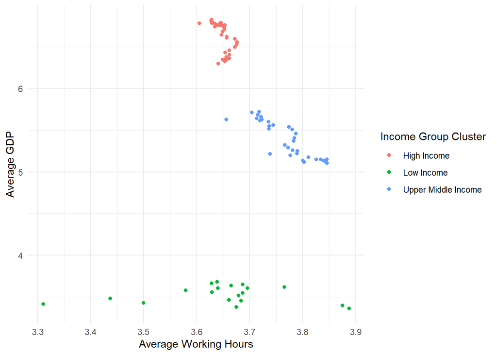

```r
ggplot(combined_df_cluster, aes(x = avg_working_hours, y = avg_gdp, color = as.factor(cluster))) +
  geom_point() +
  labs(color = "Cluster", x = "Average Working Hours", y = "Average GDP") +
  scale_color_discrete(name = "Income Group Cluster", labels = c("High Income", "Low Income", "Upper Middle Income")) +
  theme_minimal()
```

**4.3 CONCLUSION**

We were also able to also conclude that gdp earned by a employee/worker depends on country and the same amount of work may not produce the same amount of gdp across the world.

**5. REFERENCES OF DATA SOURCES**

- Data of Working Hours per Week : https://www.gapminder.org/Economy/Economic situation/Working hours per week
- Data of GDP Per capita : https://www.gapminder.org/Economy/Incomes & growth/Income
- Data of categorization of Income levels : https://www.gapminder.org/World Development Indicators/etl/notebooks/geo_mappings.csv